# Final Exam

Ferhat Turhan

06 02 2021

# Introduction

This final exam is about to create forecasting models using different approaches. Relevant data is given by the instructor. It can be found [here](https://bu-ie-360.github.io/fall20-ferhatturhan/files/production_data_with_weather.csv). It is obtained from [EPİAŞ](https://seffaflik.epias.com.tr/transparency/).

This study is about providing hourly solar power prediction for the next day. Predictions will be made by using two approaches: Forecasting with Time Series and Forecasting with Regression. Let’ first read the data and look at its behavior through time.

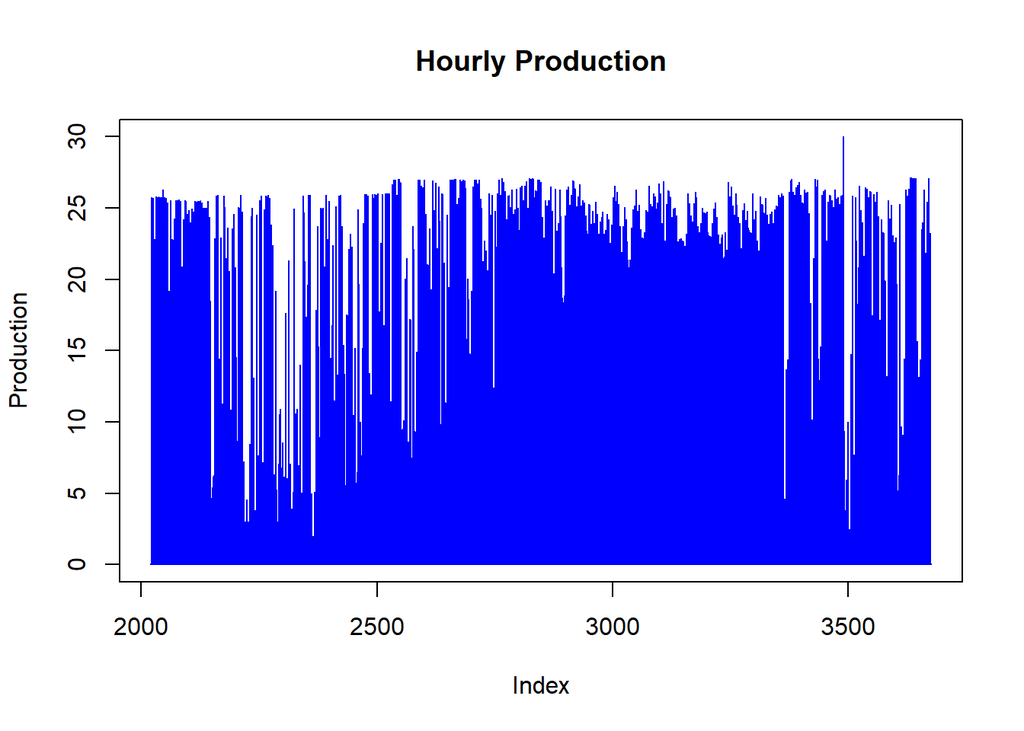

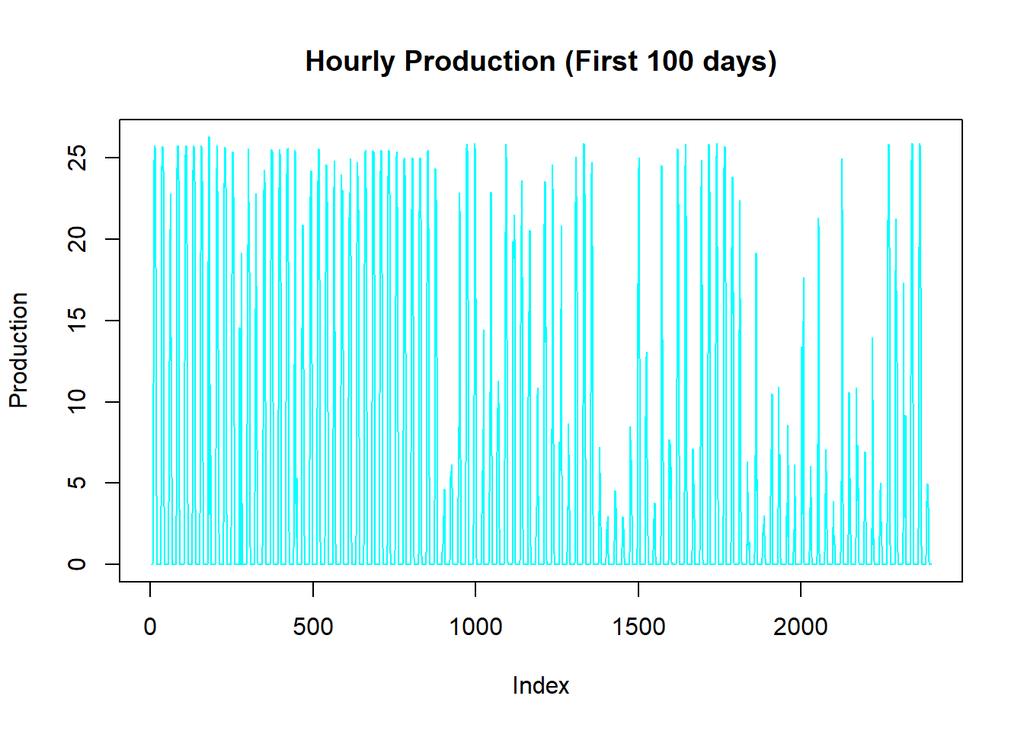

First plot is of the all data provided. However, to be able to see and interpret the behavior more accurate I also plotted the first 100 days.

The plot of the hourly production data shows that there is an obvious seasonality. There is no noticeable trend. Mean and the variance seem that they don’t change over time. Constant mean and and variance indicates that the data is stationary. Unfortunately there is a problem with this data. As expected, the production values of solar power are 0 during night hours. These values can distort our prediction models, therefore I am going to use mean of daily data and will forecast the hourly solar power by transforming the daily predictions into hourly predictions.

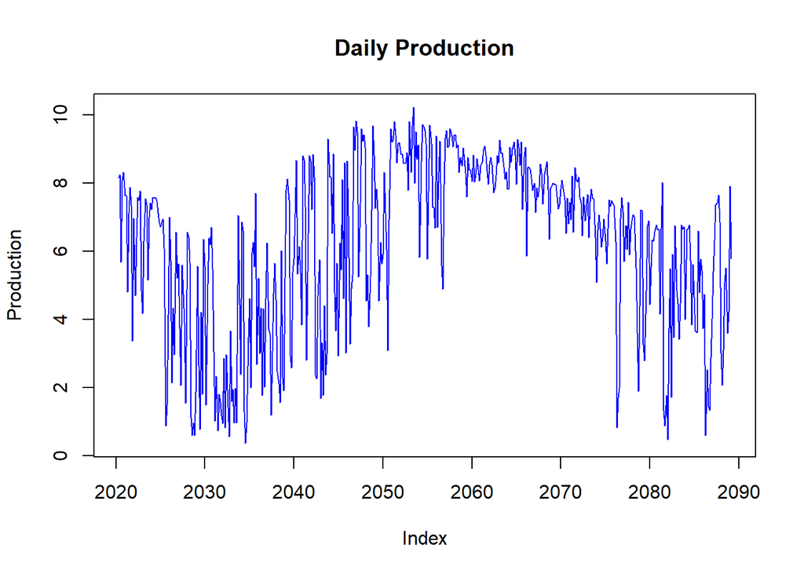

The plot of the daily production seems quite different from the plot of the hourly production. First of all the mean and variance are changing over time, indicating that daily production data is not stationary.There is also a changing trend. It looks like in the first place there is a decreasing trend which is expected due to start of winter months. After that there is a increasing trend which is also due to start of more warm days, meaning more sunny days.

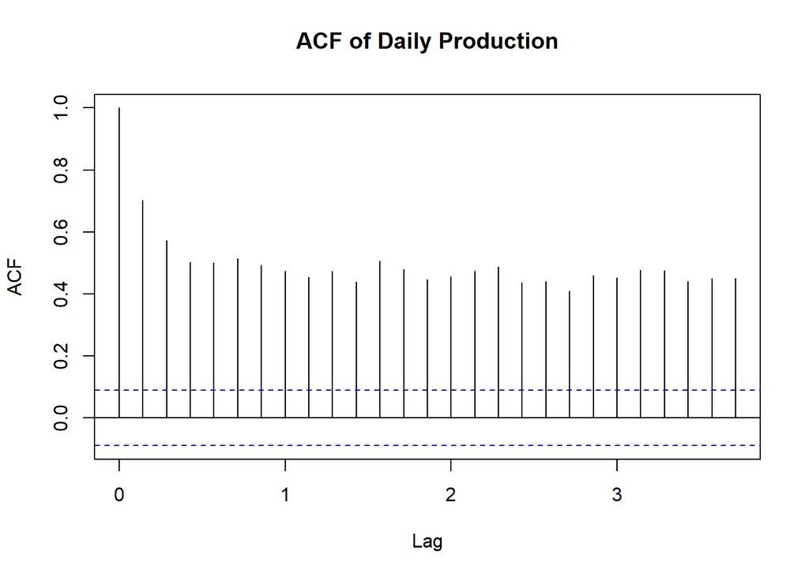

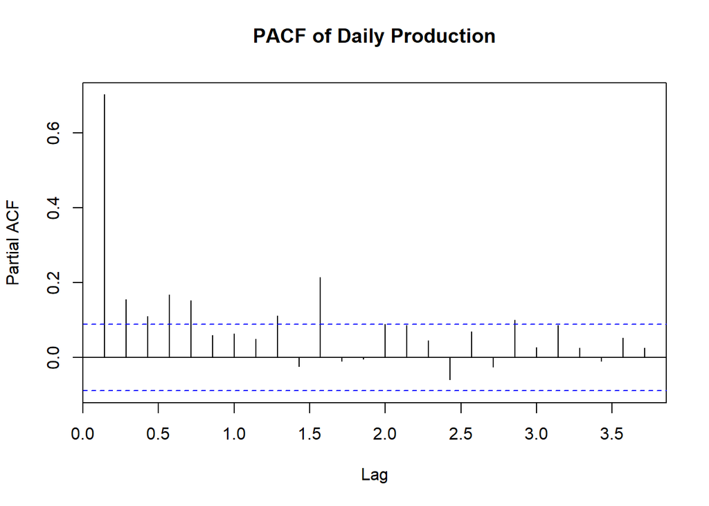

From autocorrelation function, it seems that the data is highly autocorrelated. From partial autocorrelation function it is obvious that at lag 1, daily production function is significantly correlated. I will make more comment on this when I form my models. Now let’s start with Forecasting with Time Series Analysis.

# Forecasting with Time Series

In the first place I will decompose the daily production data into its components: trend, seasonality, and random. As I discussed above there is a changing trend in the data. In addition to that, from the plot below, which is the plot for first four weeks, I think that there is a possible weekly seasonality. Moreover, since the weather is changing, it is possible that the data has monthly seasonality.

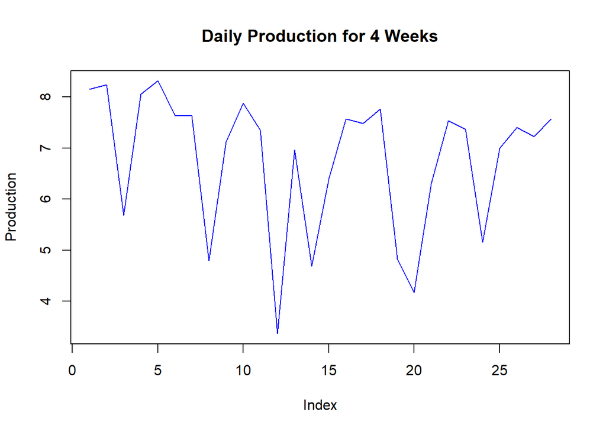

Below, one can find both additive and multiplicative decomposition of daily data.

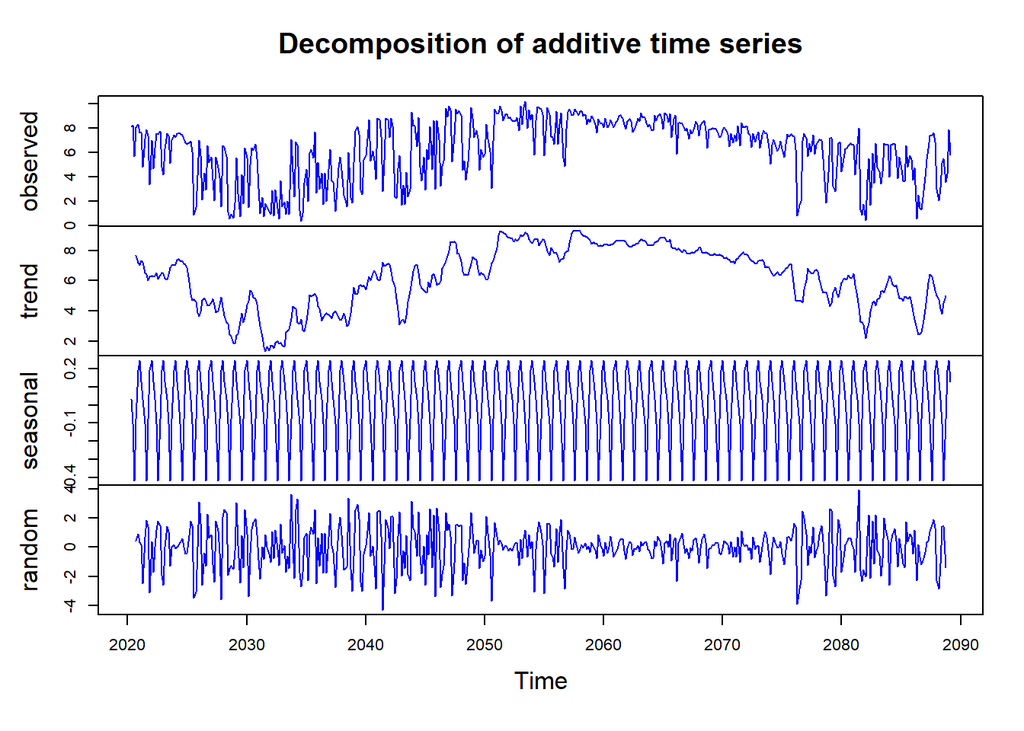

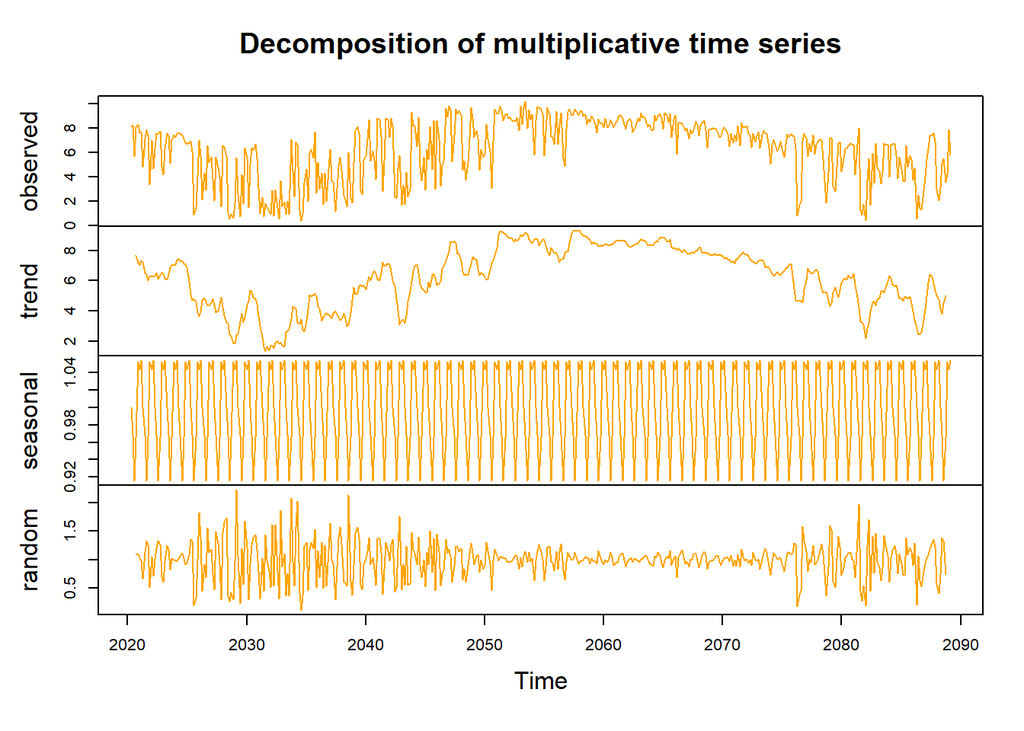

```
##
## #######################
## # KPSS Unit Root Test #
## #######################
##
## Test is of type: mu with 5 lags.
##
## Value of test-statistic is: 0.0079
##
## Critical value for a significance level of:
##                 10pct  5pct 2.5pct  1pct
## critical values 0.347 0.463  0.574 0.739
```

```
##
## #######################
## # KPSS Unit Root Test #
## #######################
##
## Test is of type: mu with 5 lags.
##
## Value of test-statistic is: 0.0194
##
## Critical value for a significance level of:
##                 10pct  5pct 2.5pct  1pct
## critical values 0.347 0.463  0.574 0.739
```

From above I told that variance is changing over time. In the first place I thought that multiplicative decomposition would be a better choice due to variations in variance, however KPSS Unit Root tests suggest the opposite. Test statistics proposes that additive decomposition is a better option here.

Now I am going to look at the acf and pacf plots so that I can propose some ARIMA models.

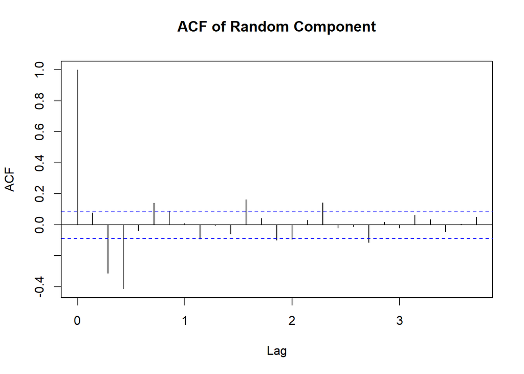

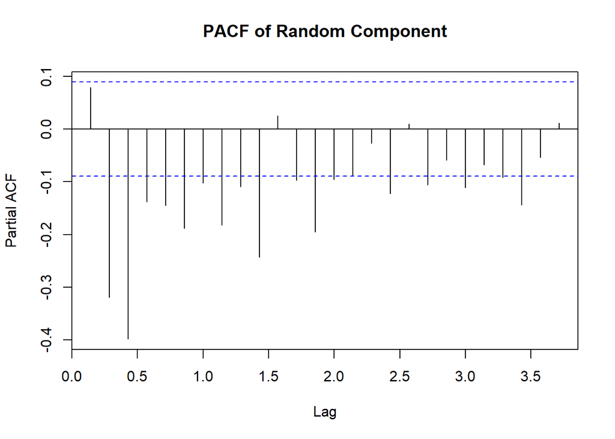

```
## [1] "Model 1"
```

```
##
## Call:
## arima(x = random1, order = c(1, 0, 1))
##
## Coefficients:
##           ar1     ma1  intercept
##       -0.2442  0.3805    -0.0002
## s.e.   0.1503  0.1385     0.0712
##
## sigma^2 estimated as 1.967:  log likelihood = -838.14,  aic = 1684.27
```

```
## [1] "Model 2"
```

```
##
## Call:
## arima(x = random1, order = c(4, 0, 1))
##
## Coefficients:
##          ar1      ar2      ar3     ar4      ma1  intercept
##       0.6419  -0.3253  -0.1917  0.0649  -1.0000      0e+00
## s.e.  0.0458   0.0536   0.0536  0.0458   0.0057      4e-04
##
## sigma^2 estimated as 1.144:  log likelihood = -712.23,  aic = 1438.46
```

```
## [1] "Model 3"
```

```
##
## Call:
## arima(x = random1, order = c(4, 0, 1), seasonal = c(0, 0, 1))
##
## Coefficients:
##          ar1      ar2      ar3     ar4      ma1     sma1  intercept
##       0.6133  -0.3089  -0.2215  0.0469  -1.0000  -0.1162      0e+00
## s.e.  0.0481   0.0533   0.0545  0.0469   0.0059   0.0546      4e-04
##
## sigma^2 estimated as 1.132:  log likelihood = -709.91,  aic = 1435.83
```

```
## [1] "Model 4"
```

```
##
## Call:
## arima(x = random1, order = c(4, 0, 1), seasonal = c(1, 0, 1))
##
## Coefficients:
##          ar1      ar2      ar3     ar4      ma1    sar1     sma1  intercept
##       0.6146  -0.3032  -0.2267  0.0460  -1.0000  0.5816  -0.6964      0e+00
## s.e.  0.0482   0.0536   0.0548  0.0471   0.0063  0.2532   0.2243      3e-04
##
## sigma^2 estimated as 1.124:  log likelihood = -708.4,  aic = 1434.8
```

```
## [1] "Auto Arima"
```

```
## Series: random1
## ARIMA(4,0,0)(0,0,1)[7] with zero mean
##
## Coefficients:
##           ar1      ar2      ar3      ar4     sma1
##       -0.0799  -0.3131  -0.4043  -0.1415  -0.0236
## s.e.   0.0456   0.0418   0.0418   0.0466   0.0500
##
## sigma^2 estimated as 1.489:  log likelihood=-769.74
## AIC=1551.48   AICc=1551.66   BIC=1576.49
```

By looking at the AIC values, model 4 is the best option so far. I also used Auto Arima if there is something better, maybe I couldn’t detect. However, model 4 seems to be a better model.

## Predictions

```r
i <- 0
training_data <- dailydata[1:481]
training_data <- training_data[419:481,mean_Production:= NA]
predictions1 <- data.table(data[10033:11544,1:2])
k<-1
while(i<=62)
{
current <- training_data[1:(418 + i)]
ts_training <- ts(current$mean_Production, frequency = 7, start = c(2019,10,09))
decomposition<-decompose(ts_training,type="additive")
random <- decomposition$random

model <- arima(random, order = c(4,0,1), seasonal = c(1,0,1))
#fit <- random - residuals(model)
#fit_transformed <- decomposition$seasonal + decomposition$trend + fit

model_forecast <- predict(model, n.ahead = 2)$pred
model_forecast <- ts(model_forecast,frequency = 7)

last_trend_value <- tail(decomposition$trend[!is.na(decomposition$trend)],1)
seasonality <- decomposition$seasonal[(418+i)]
model_forecast <- model_forecast + last_trend_value + seasonality
training_data$mean_Production[(418+i+1)] <- model_forecast[1]
j<- 1
while(j<=24)
{
ratio <- data[(9865+k-1), Production]/training_data$mean_Production[(411+i+1)]
predictions1[(k), forecast:=(training_data$mean_Production[(418+i+1)])*ratio]
j <- j+1
k <- k+1
}
i <- i+1
}
```

# Forecasting with Regression

Now that I have predicted the hourly production values with time series analysis, I move on to another approach. I will use multiple regression model. In the data provided for this study, there are lots of independent variables. In addition to those variables I will also add trend and seasonality variables. I will add those from the decomposition part. In this approach, again I will predict the daily production and then transform it into hourly predictions. First let’s turn all variables into daily mean values and add the trend and seasonality variables. After adding those variables, head of the data is below.

```
##          Date mean_Production mean1     mean2 mean3     mean4    mean5    mean6
## 1: 2019-10-09        8.150833     0 0.0000000     0 0.0000000 221.2917 221.7083
## 2: 2019-10-10        8.241250     0 0.0000000     0 0.0000000 213.6250 217.0000
## 3: 2019-10-11        5.683333     0 0.0000000     0 0.0000000 178.8750 179.8333
## 4: 2019-10-12        8.060000     0 0.2916667     0 0.5416667 215.2500 215.7500
## 5: 2019-10-13        8.316667     0 0.0000000     0 0.0000000 218.6667 219.2500
## 6: 2019-10-14        7.630833     0 0.0000000     0 0.0000000 213.5000 212.6250
##       mean7    mean8    mean9   mean10   mean11   mean12    seasonal    trend
## 1: 219.3750 221.6667 18.81850 17.88808 17.03600 15.42433  0.03157172       NA
## 2: 217.5417 218.1250 19.48413 18.55579 17.58537 15.98413 -0.10210738       NA
## 3: 168.1250 170.8750 19.41842 18.36883 17.43383 15.61758 -0.41652090       NA
## 4: 215.2083 218.0000 18.68729 18.00854 16.94896 14.96100 -0.07820218 7.673631
## 5: 218.2917 221.2500 16.89821 16.08654 15.20033 14.03154  0.19014665 7.193929
## 6: 213.5417 215.3750 19.79542 19.32708 18.17667 16.77167  0.24531384 7.033929
```

Now let’s create the very first regression model. In this model I will use all the available data and then see what can be done next.

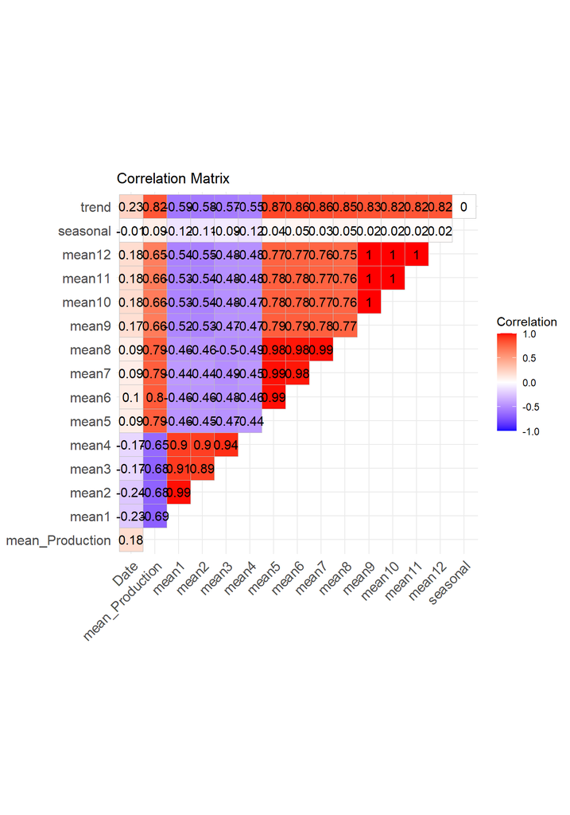

```
##
## Call:
## lm(formula = mean_Production ~ mean1 + mean2 + mean3 + mean4 +
##     mean5 + mean6 + mean7 + mean8 + mean9 + mean10 + mean11 +
##     mean12 + seasonal + trend, data = dailydata2)
##
## Residuals:
##     Min      1Q  Median      3Q     Max
## -3.7016 -0.5357  0.1240  0.7486  2.6460
##
## Coefficients:
##               Estimate Std. Error t value Pr(>|t|)
## (Intercept)  1.9571332  0.3647380   5.366 1.28e-07 ***
## mean1       -0.0459217  0.0151479  -3.032 0.002570 **
## mean2        0.0147384  0.0144451   1.020 0.308116
## mean3       -0.0052344  0.0075696  -0.692 0.489595
## mean4       -0.0004801  0.0076262  -0.063 0.949832
## mean5        0.0070751  0.0064733   1.093 0.274983
## mean6        0.0050749  0.0057819   0.878 0.380552
## mean7       -0.0069878  0.0049650  -1.407 0.159972
## mean8        0.0072043  0.0040930   1.760 0.079043 .
## mean9       -0.3681065  0.1817944  -2.025 0.043457 *
## mean10       0.5761306  0.1583554   3.638 0.000305 ***
## mean11      -0.0676950  0.1711574  -0.396 0.692647
## mean12      -0.1955825  0.0991444  -1.973 0.049125 *
## seasonal     0.2966115  0.2529029   1.173 0.241469
## trend        0.4095886  0.0636498   6.435 3.09e-10 ***
## ---
## Signif. codes:  0 '***' 0.001 '**' 0.01 '*' 0.05 '.' 0.1 ' ' 1
##
## Residual standard error: 1.122 on 462 degrees of freedom
##   (6 observations deleted due to missingness)
## Multiple R-squared:  0.8017, Adjusted R-squared:  0.7957
## F-statistic: 133.5 on 14 and 462 DF,  p-value: < 2.2e-16
```

Even though the correlation matrix shows that there are significant correlations between production and most of the independent variable, regression model says something different. From the model above, I can see that some of the provided independent variables are not significant for predicting daily solar power production values. I will remove them except seasonal variable as next step.

```
##
## Call:
## lm(formula = mean_Production ~ mean1 + mean8 + mean9 + mean10 +
##     mean12 + seasonal + trend, data = dailydata2)
##
## Residuals:
##     Min      1Q  Median      3Q     Max
## -3.9415 -0.5461  0.1429  0.7486  2.6560
##
## Coefficients:
##              Estimate Std. Error t value Pr(>|t|)
## (Intercept)  1.823636   0.350897   5.197 3.03e-07 ***
## mean1       -0.036490   0.002744 -13.299  < 2e-16 ***
## mean8        0.011557   0.001083  10.667  < 2e-16 ***
## mean9       -0.353280   0.150626  -2.345 0.019422 *
## mean10       0.540836   0.157429   3.435 0.000644 ***
## mean12      -0.240285   0.075944  -3.164 0.001657 **
## seasonal     0.329535   0.251799   1.309 0.191271
## trend        0.441423   0.061685   7.156 3.22e-12 ***
## ---
## Signif. codes:  0 '***' 0.001 '**' 0.01 '*' 0.05 '.' 0.1 ' ' 1
##
## Residual standard error: 1.126 on 469 degrees of freedom
##   (6 observations deleted due to missingness)
## Multiple R-squared:  0.7973, Adjusted R-squared:  0.7943
## F-statistic: 263.5 on 7 and 469 DF,  p-value: < 2.2e-16
```

```
##
## Call:
## lm(formula = mean_Production ~ mean1 + mean8 + mean9 + mean10 +
##     mean12 + as.factor(month) + trend, data = dailydata2)
##
## Residuals:
##     Min      1Q  Median      3Q     Max
## -3.6171 -0.5393  0.1588  0.6877  2.6056
##
## Coefficients:
##                     Estimate Std. Error t value Pr(>|t|)
## (Intercept)         0.390815   0.458968   0.852  0.39493
## mean1              -0.030365   0.003083  -9.849  < 2e-16 ***
## mean8               0.018027   0.001601  11.258  < 2e-16 ***
## mean9              -0.193902   0.161705  -1.199  0.23110
## mean10              0.478019   0.161646   2.957  0.00326 **
## mean12             -0.335218   0.083473  -4.016 6.92e-05 ***
## as.factor(month)2  -0.255364   0.265486  -0.962  0.33662
## as.factor(month)3  -0.712778   0.307472  -2.318  0.02088 *
## as.factor(month)4  -0.757485   0.365006  -2.075  0.03852 *
## as.factor(month)5  -1.318351   0.466645  -2.825  0.00493 **
## as.factor(month)6  -1.642364   0.523476  -3.137  0.00181 **
## as.factor(month)7  -1.519090   0.568002  -2.674  0.00775 **
## as.factor(month)8  -0.867423   0.522356  -1.661  0.09748 .
## as.factor(month)9  -0.442388   0.459636  -0.962  0.33632
## as.factor(month)10  0.282693   0.343379   0.823  0.41078
## as.factor(month)11  0.201721   0.236020   0.855  0.39318
## as.factor(month)12  0.363297   0.205985   1.764  0.07845 .
## trend               0.427688   0.063406   6.745 4.61e-11 ***
## ---
## Signif. codes:  0 '***' 0.001 '**' 0.01 '*' 0.05 '.' 0.1 ' ' 1
##
## Residual standard error: 1.097 on 459 degrees of freedom
##   (6 observations deleted due to missingness)
## Multiple R-squared:  0.8117, Adjusted R-squared:  0.8047
## F-statistic: 116.4 on 17 and 459 DF,  p-value: < 2.2e-16
```

Now I have a better model in terms of residual standard errors, and r-squared values. Even though some months seem that they are not significant, I won’t be removing them since I added them as seasonality effect, but I will remove the mean9 variable, since it became insignificant.

Lastly, I will try to add lag 1 value into model, since I know from previous analysis that daily production values are related with previous day.

```
##
## Call:
## lm(formula = mean_Production ~ mean1 + mean8 + mean10 + mean12 +
##     as.factor(month) + trend + lag1, data = dailydata2)
##
## Residuals:
##     Min      1Q  Median      3Q     Max
## -3.6692 -0.4919  0.1772  0.6510  2.6616
##
## Coefficients:
##                     Estimate Std. Error t value Pr(>|t|)
## (Intercept)         0.065601   0.408018   0.161 0.872337
## mean1              -0.029773   0.003124  -9.529  < 2e-16 ***
## mean8               0.017980   0.001594  11.283  < 2e-16 ***
## mean10              0.308351   0.079327   3.887 0.000116 ***
## mean12             -0.360615   0.081091  -4.447 1.09e-05 ***
## as.factor(month)2  -0.335703   0.259356  -1.294 0.196188
## as.factor(month)3  -0.751237   0.306163  -2.454 0.014509 *
## as.factor(month)4  -0.811947   0.362228  -2.242 0.025469 *
## as.factor(month)5  -1.383119   0.462445  -2.991 0.002931 **
## as.factor(month)6  -1.726921   0.516618  -3.343 0.000897 ***
## as.factor(month)7  -1.543989   0.565998  -2.728 0.006618 **
## as.factor(month)8  -0.837994   0.522085  -1.605 0.109162
## as.factor(month)9  -0.371636   0.459081  -0.810 0.418634
## as.factor(month)10  0.285822   0.342647   0.834 0.404625
## as.factor(month)11  0.229127   0.236254   0.970 0.332640
## as.factor(month)12  0.394961   0.205480   1.922 0.055207 .
## trend               0.386000   0.070823   5.450 8.23e-08 ***
## lag1                0.056183   0.036182   1.553 0.121164
## ---
## Signif. codes:  0 '***' 0.001 '**' 0.01 '*' 0.05 '.' 0.1 ' ' 1
##
## Residual standard error: 1.096 on 459 degrees of freedom
##   (6 observations deleted due to missingness)
## Multiple R-squared:  0.8121, Adjusted R-squared:  0.8051
## F-statistic: 116.7 on 17 and 459 DF,  p-value: < 2.2e-16
```

It seems that lag1 isn’t as good as I expected. It is probably due to the existence of trend variables. Because the best model up to now is the third one, I will use model 3 and add outlier residuals.

```
##
## Call:
## lm(formula = mean_Production ~ mean1 + mean8 + mean10 + mean12 +
##     as.factor(month) + trend + outlier_great + outlier_small,
##     data = dailydata2)
##
## Residuals:
##      Min       1Q   Median       3Q      Max
## -2.11709 -0.39939  0.08811  0.50203  1.76783
##
## Coefficients:
##                     Estimate Std. Error t value Pr(>|t|)
## (Intercept)         0.601525   0.306507   1.963 0.050308 .
## mean1              -0.034408   0.002224 -15.473  < 2e-16 ***
## mean8               0.016542   0.001140  14.508  < 2e-16 ***
## mean10              0.234838   0.058261   4.031 6.51e-05 ***
## mean12             -0.279873   0.059300  -4.720 3.14e-06 ***
## as.factor(month)2  -0.178198   0.185548  -0.960 0.337367
## as.factor(month)3  -0.498966   0.220363  -2.264 0.024023 *
## as.factor(month)4  -0.389698   0.262469  -1.485 0.138300
## as.factor(month)5  -1.254586   0.332381  -3.775 0.000181 ***
## as.factor(month)6  -1.536743   0.371161  -4.140 4.13e-05 ***
## as.factor(month)7  -1.442752   0.405890  -3.555 0.000418 ***
## as.factor(month)8  -0.722512   0.373926  -1.932 0.053947 .
## as.factor(month)9  -0.400122   0.328257  -1.219 0.223498
## as.factor(month)10  0.307232   0.244560   1.256 0.209662
## as.factor(month)11  0.199862   0.168950   1.183 0.237437
## as.factor(month)12  0.463977   0.146930   3.158 0.001695 **
## trend               0.435530   0.045350   9.604  < 2e-16 ***
## outlier_great       1.748436   0.172666  10.126  < 2e-16 ***
## outlier_small      -2.944748   0.172716 -17.050  < 2e-16 ***
## ---
## Signif. codes:  0 '***' 0.001 '**' 0.01 '*' 0.05 '.' 0.1 ' ' 1
##
## Residual standard error: 0.7839 on 458 degrees of freedom
##   (6 observations deleted due to missingness)
## Multiple R-squared:  0.9041, Adjusted R-squared:  0.9003
## F-statistic: 239.8 on 18 and 458 DF,  p-value: < 2.2e-16
```

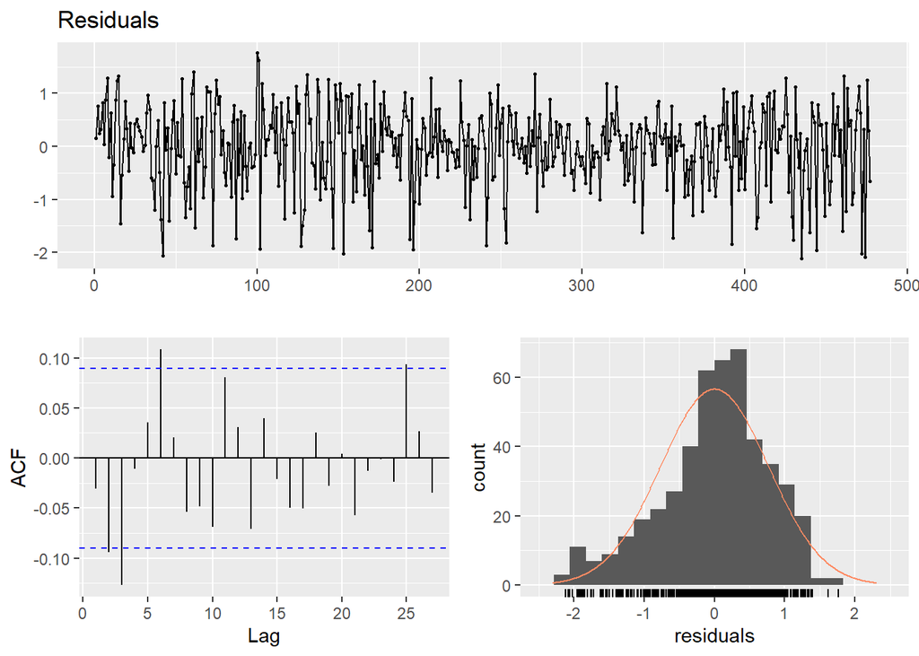

```
##
##  Breusch-Godfrey test for serial correlation of order up to 22
##
## data:  Residuals
## LM test = 37.556, df = 22, p-value = 0.02054
```

It can be seen that outliers made the model much better in terms of residual standard error and r-squared values. Also, when we check the residuals, they don’t violate much the assumptions of being normally distributed, having zero mean, and not being autocorrelated. I am going to use this model for my predictions.

## Predictions

```r
i <- 0
training_data2 <- dailydata2[1:481]
training_data2 <- training_data2[419:481,mean_Production:= NA]
training_data2 <- training_data2[420:481,lag1:= NA]
training_data2 <- training_data2[419:481,outlier_great:= 0]
training_data2 <- training_data2[419:481,outlier_small:= 0]
training_data2$trend[481] <- training_data2$trend[480]
predictions2 <- data.table(data[10033:11544,1:2])
k<-1
while(i<=62)
{
current2 <- training_data2[1:(419 + i)]

fit <- lm(mean_Production~mean1+mean8+mean10+mean12+as.factor(month)+trend+outlier_great+outlier_small, current2)
current2[4:(418+i),fitted:=fitted(fit)]
current2[is.na(fitted)==T,fitted:=predict(fit, current2[418+i+1])]

training_data2$mean_Production[(418+i+1)] <- current2$fitted[418+i+1]
j<- 1
while(j<=24)
{
ratio <- data[(9865+k-1), Production]/training_data2$mean_Production[(411+i+1)]
predictions2[(k), forecast:=(training_data2$mean_Production[(418+i+1)])*ratio]
j <- j+1
k <- k+1
}
i <- i+1
}
```

Now that I have predicted the test period with 2 different approaches, I will compare the two by calculating error statistics.

# Comparison of Models

```
## [1] "Statistics for Time Series Approach"
```

```
##      n    mean      sd       bias      mad     wmape
## 1 1512 4.75203 8.15294 -0.0432457 2.751874 0.5790943
```

```
## [1] "Statistics for Regression Approach"
```

```
##      n    mean      sd       bias    mad     wmape
## 1 1512 4.75203 8.15294 -0.1018068 2.5905 0.5451354
```

From the test statistics above I can say that the model in which regression approach used is a better one according to weighted mean absolute percentage error(WMAPE). I will be using that model for my final forecasts. This WMAPE values are quite high. I think the main problem in those models are in transforming the daily data into hourly values. Transforming approach could be done better by using other approaches. For example, instead of using only the previous weeks’ ratios, I could have create another algorithm using weather data or something else. I am curious if the only problem was transforming the daily predictions into hourly predictions. Below I calculated the statistics of daily predictions.

```
## [1] "Statistics for Time Series Approach -Daily- "
```

```
##    n    mean       sd       bias      mad     wmape
## 1 63 4.75203 1.951728 -0.0432457 2.516993 0.5296667
```

```
## [1] "Statistics for Regression Approach -Daily- "
```

```
##    n    mean       sd       bias      mad     wmape
## 1 63 4.75203 1.951728 -0.1018068 2.154052 0.4532909
```

When I look at the WMAPE values of daily predictions, I can say that both model are better than hourly predictions. This demonstrates that transforming phase was a huge problem. However, WMAPE values are still not good enough for daily predictions especially for the first model. I can say that I could have used better ARIMA models and maybe more manipulations to make the time series more stationary. For regression part, I didn’t make much research on independent X variables. Maybe if I have more information about them, I could have used them more efficient.

# Conclusion

To conclude, I have forecasted hourly solar power production for a period of two months. I did this study by using two different forecasting approaches: Forecasting with Time Series and Forecasting with Regression. After creating different models for both approaches, I selected the best ones from my observations. After that I compared two models of the two approaches, using the test statistic WMAPE on forecasts for test period. In the comparison part of the study I also discussed possible differences which could have made models better.

My research for this study showed that in terms of predicting the solar power production, regression approach is a better approach for predicting. Below one can find the final predictions.

```
##             Date Hour     forecast
##    1: 2020-11-30    0 0.000000e+00
##    2: 2020-11-30    1 0.000000e+00
##    3: 2020-11-30    2 0.000000e+00
##    4: 2020-11-30    3 0.000000e+00
##    5: 2020-11-30    4 0.000000e+00
##    6: 2020-11-30    5 0.000000e+00
##    7: 2020-11-30    6 0.000000e+00
##    8: 2020-11-30    7 1.715974e-01
##    9: 2020-11-30    8 4.656530e+00
##   10: 2020-11-30    9 1.246421e+01
##   11: 2020-11-30   10 1.777593e+01
##   12: 2020-11-30   11 2.053709e+01
##   13: 2020-11-30   12 2.107528e+01
##   14: 2020-11-30   13 2.063849e+01
```

[output cut: 1499 more lines]

# References

[EPİAŞ](https://seffaflik.epias.com.tr/transparency/)

You can find the related R Markdown file and related R Codes [here](https://bu-ie-360.github.io/fall20-ferhatturhan/files/final.Rmd)